# PShaji_Assignment15

WebTest Name- (Test)

Priya Shaji

12/2/2019

1. Find the equation of the regression line for the given points. Round any final values to the nearest hundredth, if necessary. (5.6,8.8), (6.3,12.4), (7,14.8), (7.7,18.2), (8.4,20.8)

**Answer 1)**

```r
df = data.frame(rbind(c( 5.6, 8.8 ), c( 6.3, 12.4 ), c( 7, 14.8 ), c( 7.7, 18.2 ), c( 8.4, 20.8 )))
```

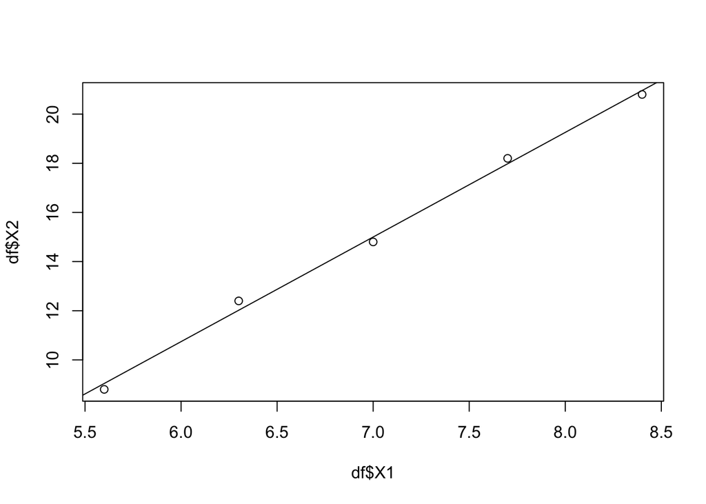

```r
model <- lm(df$X2 ~ df$X1, df)
plot(df$X2~df$X1,data=df)
abline(model)
```

2. Find all local maxima, local minima, and saddle points for the function given below. Write your answer(s) in the form ( x, y, z ). Separate multiple points with a comma.

$f(x,y)=24x-6xy^2-8y^3$

**Answer 2)**

Let us find the first and second partial derivatives:

$df/dx=24−6y^2df/dy=−12xy−24y^2$

$d^2f/dx=0d^2f/dy=−12x−48y$

$df/dx=24−6y^2=0−>4−y^2=0df/dy=−12xy−24y^2=0−>−xy−2y^2=0$

y=+/-2. when y=2 and x=-4 and when y=-2 then x=4.

Therefore, the points are (4,-2) and (-4,2).

$for (4,-2) f(x,y)=24∗4−6∗4∗(−2)^2−8(−2)^3=64$

which is > 0$

$for (-4,2) f(x,y)=24∗−4−(6∗−4∗(2)^2)−8(2)^3=−64$

which is < 0$

3. A grocery store sells two brands of a product, the “house” brand and a “name” brand. The manager estimates that if she sells the “house” brand for x dollars and the “name” brand for y dollars, she will be able to sell 81 - 21x + 17y units of the “house” brand and 40 + 11x - 23y units of the “name” brand.

Step 1. Find the revenue function R ( x, y ).

**Answer 3)**

House brand: R(x)=x∗(81−21x+17y)

Name brand: R(y)=y∗(40+11x−23y)

total_revenue = $R(x,y)=x∗(81−21x+17y)+y∗(40+11x−23y) -> - 21x^2 - 23y^2 + 28xy + 81x + 40y$

Step 2. What is the revenue if she sells the “house” brand for $2.30 and the “name” brand for $4.10?

```r
x = 2.3
y = 4.1
total_revenue <- -21*x^2 - 23*y^2 + 28*x*y + 81*x + 40*y

print(total_revenue)
```

```
## [1] 116.62
```

Therefore,

we get $116.62 if they sell at $2.3 and $4.1

4. A company has a plant in Los Angeles and a plant in Denver. The firm is committed to produce a total of 96 units of a product each week. The total weekly cost is given by C(x,y)= 1x2 + 1y2 +7x+25y+700, where x is the number of 66 units produced in Los Angeles and y is the number of units produced in Denver. How many units should be produced in each plant to minimize the total weekly cost?

**Answer 4)**

x+y=96

5. Evaluate the double integral on the given region. $\int\int(e^{8x+3y})dA; R:2<=x<=4 and 2<=y<=4$

Write your answer in exact form without decimals.

**Answer 5)**

$=\int^{4}_{2}\int^{4}_{2}(e^{8x}e^{3y}) dx dy$

$=\int^{4}_{2}1/8e^{3y+32}−1/8e^{3y+16} dy$

$=\int^{4}_{2}1/8(e^{16}−1)e^{3y+16} dy$

$=(e^44−e^28)/24−(e^{38}−e^{22})/24$

$=1/24(e^{22}−e^{28}−e^{38}+e^{44})$